# Impact of Soil Composition and Irrigation Practices on Crop Development Outcomes

```python
import pandas as pd
```

```python
df=pd.read_csv(r"plant_growth_data.csv")
```

## What is the relative importance of soil type, fertilizer type, and water frequency in predicting plant growth milestones?

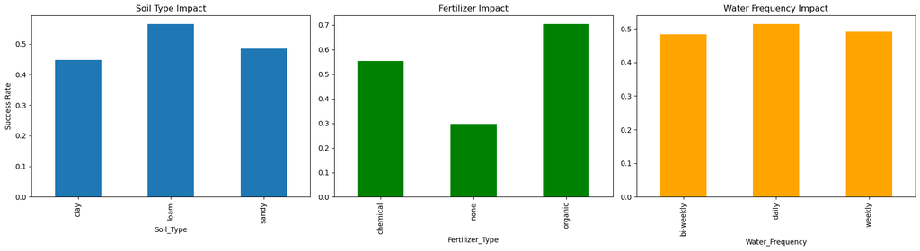

```python
import pandas as pd
import matplotlib.pyplot as plt

# Load data
df = pd.read_csv(r'plant_growth_data.csv')

# Calculate success rates
soil_success = df.groupby('Soil_Type')['Growth_Milestone'].mean()
fert_success = df.groupby('Fertilizer_Type')['Growth_Milestone'].mean()
water_success = df.groupby('Water_Frequency')['Growth_Milestone'].mean()

# Plot
fig, axes = plt.subplots(1, 3, figsize=(18, 5))
soil_success.plot(kind='bar', ax=axes[0], title='Soil Type Impact', ylabel='Success Rate')
fert_success.plot(kind='bar', ax=axes[1], title='Fertilizer Impact', color='green')
water_success.plot(kind='bar', ax=axes[2], title='Water Frequency Impact', color='orange')
plt.tight_layout()
plt.savefig("Water Frequency Impact.png")
plt.show()
```

## How does the interaction between soil type (e.g., clay vs. sandy) and fertilizer type (organic/chemical/none) influence growth success?

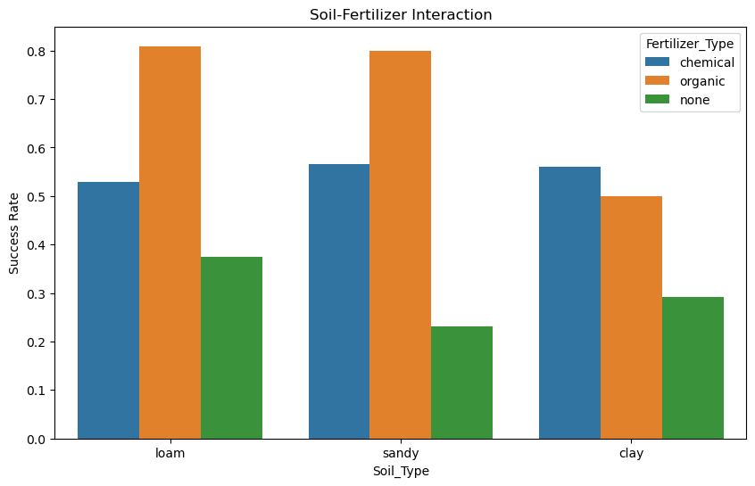

```python
import seaborn as sns

# Cross-tabulation
cross_table = df.groupby(['Soil_Type', 'Fertilizer_Type'])['Growth_Milestone'].mean().unstack()

# Plot
plt.figure(figsize=(10, 6))
sns.barplot(data=df, x='Soil_Type', y='Growth_Milestone', hue='Fertilizer_Type', errorbar=None)
plt.title('Soil-Fertilizer Interaction')
plt.ylabel('Success Rate')
plt.savefig("Soil-Fertilizer Interaction.png")
plt.show()
```

## Is there an optimal sunlight duration range (e.g., 4–8 hours) that maximizes growth milestones across different soil types?

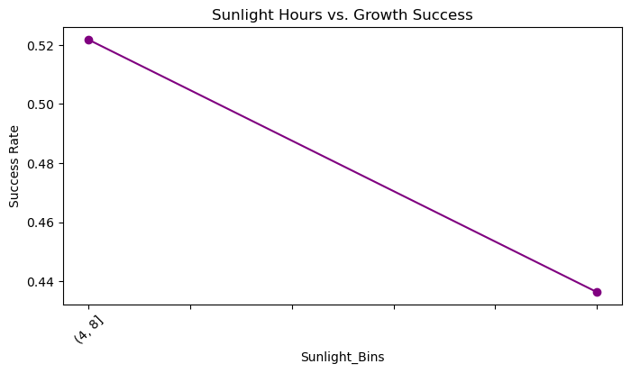

```python
# Bin sunlight hours
df['Sunlight_Bins'] = pd.cut(df['Sunlight_Hours'], bins=[0, 4, 8, 10])
sunlight_success = df.groupby('Sunlight_Bins',observed=True)['Growth_Milestone'].mean()

# Plot
plt.figure(figsize=(8, 4))
sunlight_success.plot(kind='line', marker='o', color='purple')
plt.title('Sunlight Hours vs. Growth Success')
plt.ylabel('Success Rate')
plt.xticks(rotation=45)
plt.savefig("Sunlight Hours vs. Growth Success.png")
plt.show()
```

## Do plants grown with organic fertilizers outperform those with chemical fertilizers in specific temperature or humidity ranges?

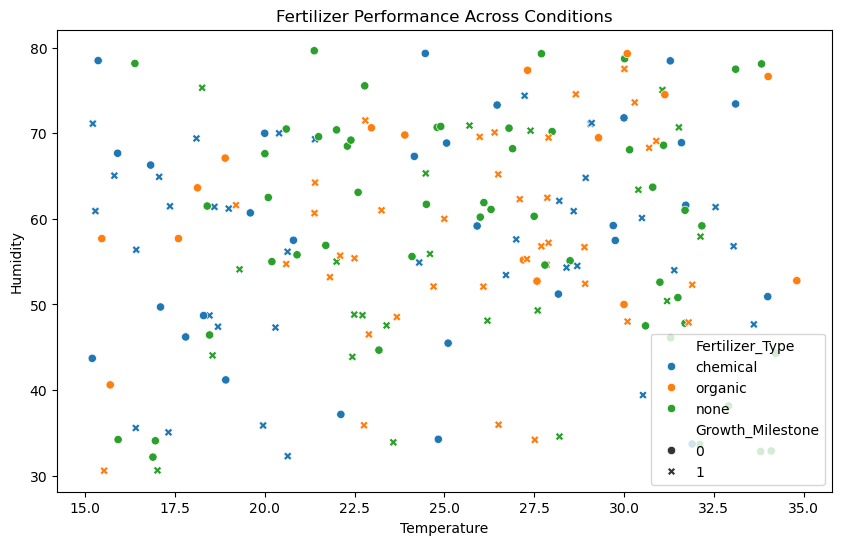

```python
plt.figure(figsize=(10, 6))
sns.scatterplot(data=df, x='Temperature', y='Humidity', hue='Fertilizer_Type', style='Growth_Milestone')
plt.title('Fertilizer Performance Across Conditions')
plt.savefig("Fertilizer Performance Across Conditions.png")
plt.show()
```

## How does water frequency (daily, weekly, bi-weekly) affect growth outcomes when combined with varying soil types?

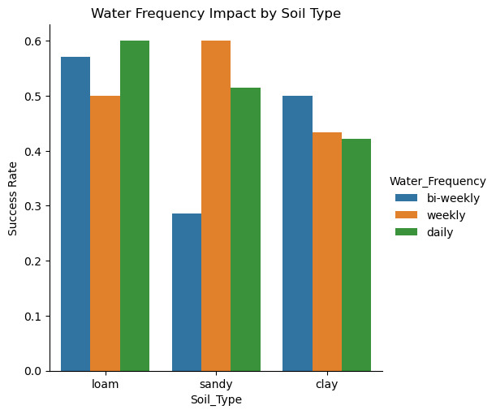

```python
sns.catplot(data=df, x='Soil_Type', y='Growth_Milestone', hue='Water_Frequency', kind='bar', errorbar=None)
plt.title('Water Frequency Impact by Soil Type')
plt.ylabel('Success Rate')
plt.savefig("Water Frequency Impact by Soil Type.png")
plt.show()
```

## Are there threshold values for temperature or humidity beyond which growth milestones become significantly less likely?

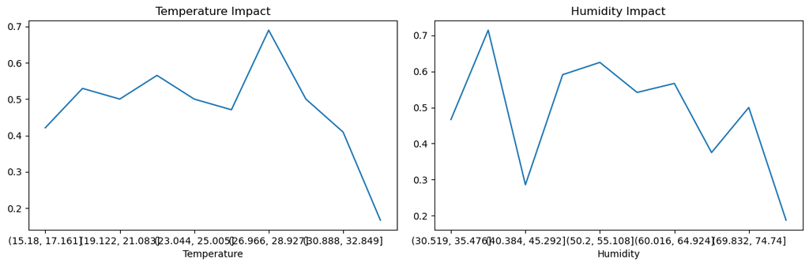

```python
fig, axes = plt.subplots(1, 2, figsize=(12, 4))
df.groupby(pd.cut(df['Temperature'], bins=10),observed=True)['Growth_Milestone'].mean().plot(ax=axes[0], title='Temperature Impact')
df.groupby(pd.cut(df['Humidity'], bins=10),observed=True)['Growth_Milestone'].mean().plot(ax=axes[1], title='Humidity Impact')
plt.tight_layout()
plt.savefig("Humidity Impact.png")
plt.show()
```

## Does the absence of fertilizer disproportionately impact growth in certain soil types (e.g., sandy vs. loam)?

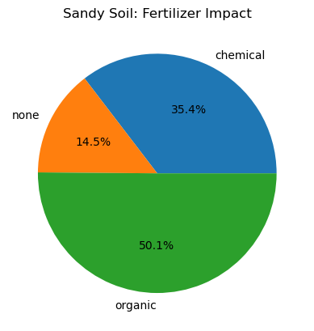

```python
sandy = df[df['Soil_Type'] == 'sandy']
sandy_fert = sandy.groupby('Fertilizer_Type')['Growth_Milestone'].mean()

plt.pie(sandy_fert, labels=sandy_fert.index, autopct='%1.1f%%')
plt.title('Sandy Soil: Fertilizer Impact')
plt.savefig("Sandy Soil: Fertilizer Impact.png")
plt.show()
```

## How do extreme environmental conditions (e.g., high temperature + low humidity) interact with fertilizer choices to suppress or enhance growth?

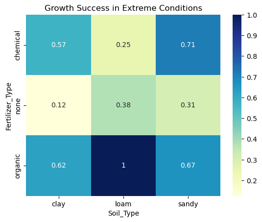

```python
# Define extreme conditions
extreme = df[(df['Temperature'] > 30) | (df['Humidity'] < 40)]
cross_extreme = extreme.groupby(['Fertilizer_Type', 'Soil_Type'])['Growth_Milestone'].mean().unstack()

sns.heatmap(cross_extreme, annot=True, cmap='YlGnBu')
plt.title('Growth Success in Extreme Conditions')
plt.savefig("Growth Success in Extreme Conditions.png")
plt.show()
```

## Is there a non-linear relationship between sunlight exposure and growth milestones (e.g., diminishing returns beyond a certain threshold)?

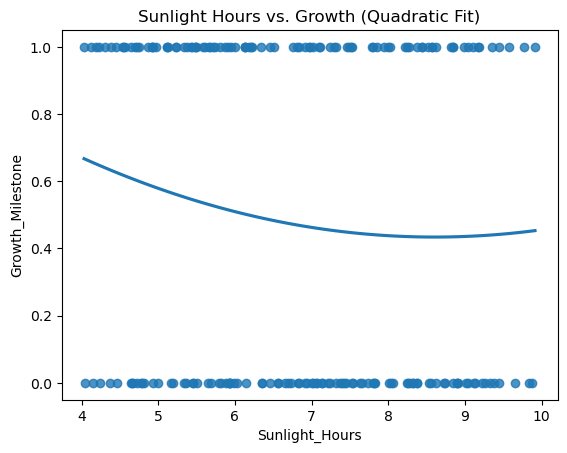

```python
sns.regplot(x=df['Sunlight_Hours'], y=df['Growth_Milestone'], order=2, ci=None)
plt.title('Sunlight Hours vs. Growth (Quadratic Fit)')
plt.savefig("Sunlight Hours vs. Growth.png")
plt.show()
```

## Do specific soil-fertilizer combinations mitigate the negative effects of suboptimal watering schedules?

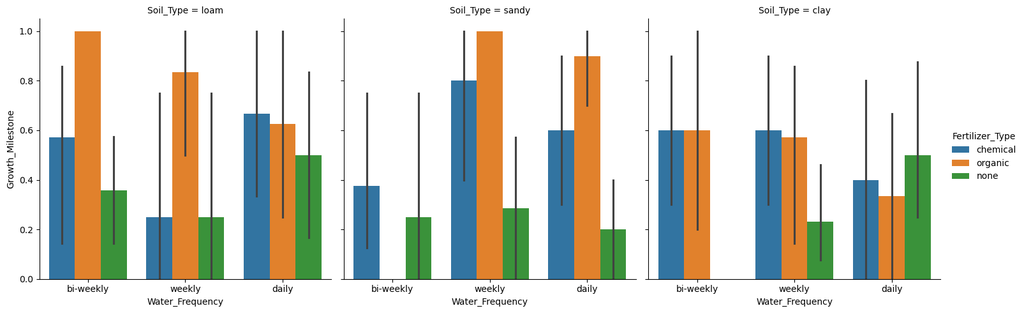

```python
sns.catplot(data=df, x='Water_Frequency', y='Growth_Milestone', col='Soil_Type', hue='Fertilizer_Type', kind='bar')
plt.savefig("fertilizer combinations.png")
plt.show()
```

## How does humidity modulate the effectiveness of chemical fertilizers compared to organic alternatives?

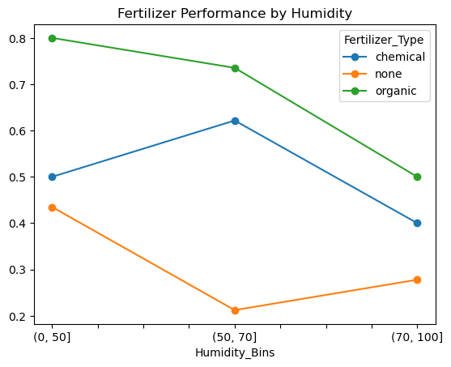

```python
df['Humidity_Bins'] = pd.cut(df['Humidity'], bins=[0, 50, 70, 100])
humidity_fert = df.groupby(['Humidity_Bins', 'Fertilizer_Type'],observed=True)['Growth_Milestone'].mean().unstack()

humidity_fert.plot(kind='line', marker='o')
plt.title('Fertilizer Performance by Humidity')
plt.savefig("Fertilizer Performance by Humidity.png")
plt.show()
```

## Are certain soil types inherently more resilient to fluctuations in temperature or water frequency?

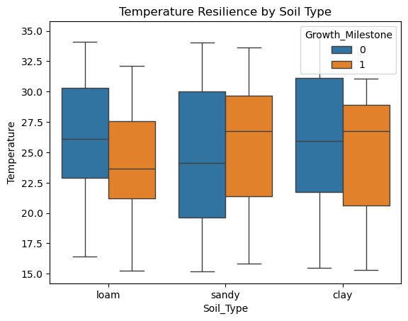

```python
sns.boxplot(data=df, x='Soil_Type', y='Temperature', hue='Growth_Milestone')
plt.title('Temperature Resilience by Soil Type')
plt.savefig("Temperature Resilience by Soil Type.png")
plt.show()
```

## Do plants in loam soil exhibit statistically significant growth advantages over clay or sandy soils under identical environmental conditions?

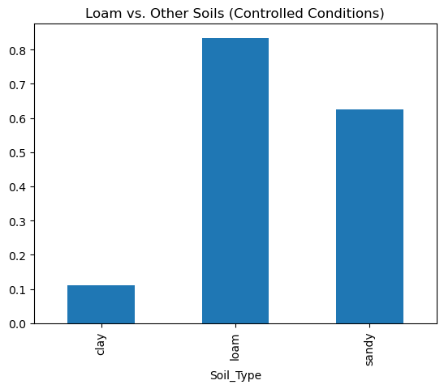

```python
filtered = df[(df['Sunlight_Hours'].between(6, 8)) & (df['Temperature'].between(20, 25))]
filtered.groupby('Soil_Type')['Growth_Milestone'].mean().plot(kind='bar')
plt.title('Loam vs. Other Soils (Controlled Conditions)')
plt.savefig("Loam vs. Other Soils.png")
plt.show()
```